# Copepod Species Richness: Spatial Exploration and Mapping

Kendra Sturdee

2026-10-06

# Introduction

This workshop explores spatial patterns in copepod species richness using sampling records, sea surface temperature and spatial reference layers around Australia.The analysis demonstrates data exploration, coordinate reference systems, spatial transformations and thematic mapping using R.

## Load copepode data

```
## Rows: 5,313
## Columns: 11
## $ silk_id         <dbl> 1, 1, 1, 1, 1, 1, 1, 1, 1, 1, 1, 1, 1, 2, 2, 2, 2, 2, 2, 2,…
## $ segment_no      <dbl> 1, 5, 9, 13, 17, 18, 26, 30, 33, 37, 41, 45, 49, 1, 5, 9, 1…
## $ latitude        <dbl> -28.34227, -28.67602, -29.00665, -29.33726, -29.66785, -29.…
## $ longitude       <dbl> 153.8139, 153.8109, 153.7558, 153.7003, 153.6445, 153.6305,…
## $ sample_time_utc <chr> "26/06/2009 22:08", "26/06/2009 23:12", "27/06/2009 0:17", …
## $ project         <chr> "AusCPR", "AusCPR", "AusCPR", "AusCPR", "AusCPR", "AusCPR",…
## $ route           <chr> "BRSY", "BRSY", "BRSY", "BRSY", "BRSY", "BRSY", "BRSY", "BR…
## $ vessel          <chr> "ANL Windarra", "ANL Windarra", "ANL Windarra", "ANL Windar…
## $ meanlong        <dbl> 153.2466, 153.2466, 153.2466, 153.2466, 153.2466, 153.2466,…
## $ region          <chr> "East", "East", "East", "East", "East", "East", "East", "Ea…
## $ richness_raw    <dbl> 3, 21, 27, 54, 24, 18, 36, 9, 24, 36, 12, 45, 27, 3, 0, 3, …
```

For processing, silks are divided into segments based on the `silk_id`. Each segment represents a unique sampling event, and the data can be grouped accordingly for analysis.

## Data exploration

Check coordinates

[figure not shown]

## Check other patterns in the data

Visualise species richness in a non-spatial way

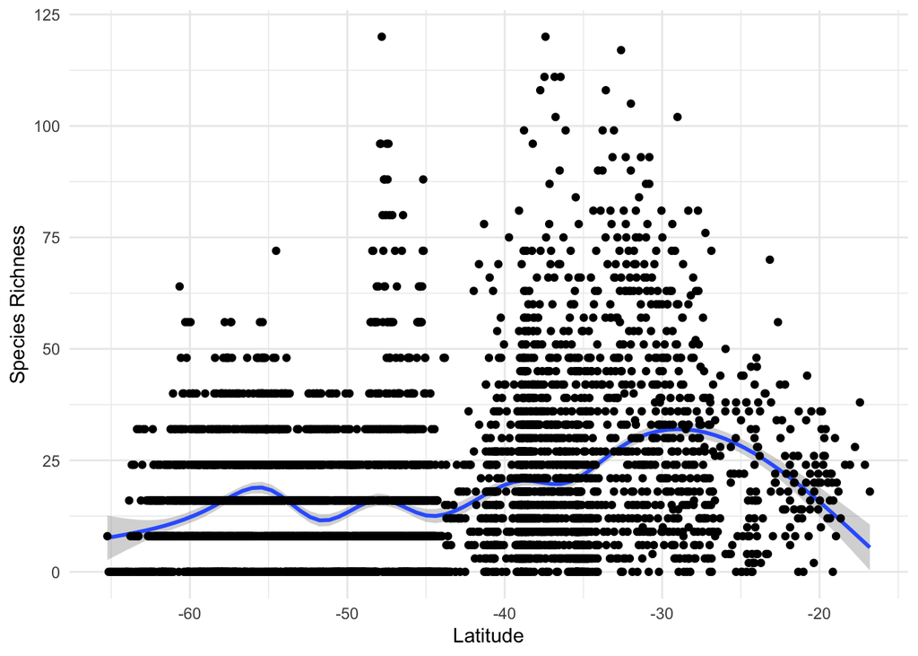

From this we can see there is an unatural change in the data pattern at around latitude -44.

Do the same thing with longitude

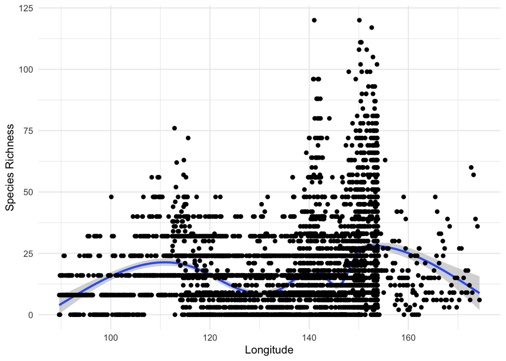

```
## # A tibble: 1 × 8
##   n_samples n_unique_silk_id min_latitude max_latitude min_longitude max_longitude
##       <int>            <int>        <dbl>        <dbl>         <dbl>         <dbl>
## 1      5313              179        -65.2        -16.8          89.6          174.
## # ℹ 2 more variables: mean_richness_raw <dbl>, sd_richness_raw <dbl>
```

## Maps

```
## Coordinate Reference System:
##   User input: EPSG:4326
##   wkt:
## GEOGCRS["WGS 84",
##     ENSEMBLE["World Geodetic System 1984 ensemble",
##         MEMBER["World Geodetic System 1984 (Transit)"],
##         MEMBER["World Geodetic System 1984 (G730)"],
##         MEMBER["World Geodetic System 1984 (G873)"],
##         MEMBER["World Geodetic System 1984 (G1150)"],
##         MEMBER["World Geodetic System 1984 (G1674)"],
##         MEMBER["World Geodetic System 1984 (G1762)"],
##         MEMBER["World Geodetic System 1984 (G2139)"],
##         MEMBER["World Geodetic System 1984 (G2296)"],
##         ELLIPSOID["WGS 84",6378137,298.257223563,
##             LENGTHUNIT["metre",1]],
##         ENSEMBLEACCURACY[2.0]],
##     PRIMEM["Greenwich",0,
##         ANGLEUNIT["degree",0.0174532925199433]],
##     CS[ellipsoidal,2],
##         AXIS["geodetic latitude (Lat)",north,
##             ORDER[1],
##             ANGLEUNIT["degree",0.0174532925199433]],
##         AXIS["geodetic longitude (Lon)",east,
##             ORDER[2],
##             ANGLEUNIT["degree",0.0174532925199433]],
##     USAGE[
##         SCOPE["Horizontal component of 3D system."],
##         AREA["World."],
##         BBOX[-90,-180,90,180]],
##     ID["EPSG",4326]]
```

```
## Simple feature collection with 5313 features and 9 fields
## Geometry type: POINT
## Dimension:     XY
## Bounding box:  xmin: 89.6107 ymin: -65.2428 xmax: 174.335 ymax: -16.80253
## Geodetic CRS:  WGS 84
## # A tibble: 5,313 × 10
##    silk_id segment_no sample_time_utc  project route vessel       meanlong region
##  *   <dbl>      <dbl> <chr>            <chr>   <chr> <chr>           <dbl> <chr>
##  1       1          1 26/06/2009 22:08 AusCPR  BRSY  ANL Windarra     153. East
##  2       1          5 26/06/2009 23:12 AusCPR  BRSY  ANL Windarra     153. East
##  3       1          9 27/06/2009 0:17  AusCPR  BRSY  ANL Windarra     153. East
##  4       1         13 27/06/2009 1:22  AusCPR  BRSY  ANL Windarra     153. East
##  5       1         17 27/06/2009 2:26  AusCPR  BRSY  ANL Windarra     153. East
##  6       1         18 27/06/2009 2:43  AusCPR  BRSY  ANL Windarra     153. East
##  7       1         26 27/06/2009 4:52  AusCPR  BRSY  ANL Windarra     153. East
##  8       1         30 27/06/2009 5:57  AusCPR  BRSY  ANL Windarra     153. East
##  9       1         33 27/06/2009 6:45  AusCPR  BRSY  ANL Windarra     153. East
## 10       1         37 27/06/2009 7:50  AusCPR  BRSY  ANL Windarra     153. East
## # ℹ 5,303 more rows
## # ℹ 2 more variables: richness_raw <dbl>, geometry <POINT [°]>
```

Must decide how to project the data. Projections are defined by a projected coordinate reference system (CRS) that transforms the curved surface of the Earth into a flat plane. The choice of projection can affect the accuracy and interpretation of spatial data, especially for analyses involving distances, areas, and spatial relationships.

```
## Simple feature collection with 5313 features and 9 fields
## Geometry type: POINT
## Dimension:     XY
## Bounding box:  xmin: 89.6107 ymin: -65.2428 xmax: 174.335 ymax: -16.80253
## Geodetic CRS:  WGS 84
## # A tibble: 5,313 × 10
##    silk_id segment_no sample_time_utc  project route vessel       meanlong region
##  *   <dbl>      <dbl> <chr>            <chr>   <chr> <chr>           <dbl> <chr>
##  1       1          1 26/06/2009 22:08 AusCPR  BRSY  ANL Windarra     153. East
##  2       1          5 26/06/2009 23:12 AusCPR  BRSY  ANL Windarra     153. East
##  3       1          9 27/06/2009 0:17  AusCPR  BRSY  ANL Windarra     153. East
##  4       1         13 27/06/2009 1:22  AusCPR  BRSY  ANL Windarra     153. East
##  5       1         17 27/06/2009 2:26  AusCPR  BRSY  ANL Windarra     153. East
##  6       1         18 27/06/2009 2:43  AusCPR  BRSY  ANL Windarra     153. East
##  7       1         26 27/06/2009 4:52  AusCPR  BRSY  ANL Windarra     153. East
##  8       1         30 27/06/2009 5:57  AusCPR  BRSY  ANL Windarra     153. East
##  9       1         33 27/06/2009 6:45  AusCPR  BRSY  ANL Windarra     153. East
## 10       1         37 27/06/2009 7:50  AusCPR  BRSY  ANL Windarra     153. East
## # ℹ 5,303 more rows
## # ℹ 2 more variables: richness_raw <dbl>, geometry <POINT [°]>
```

## Cartography

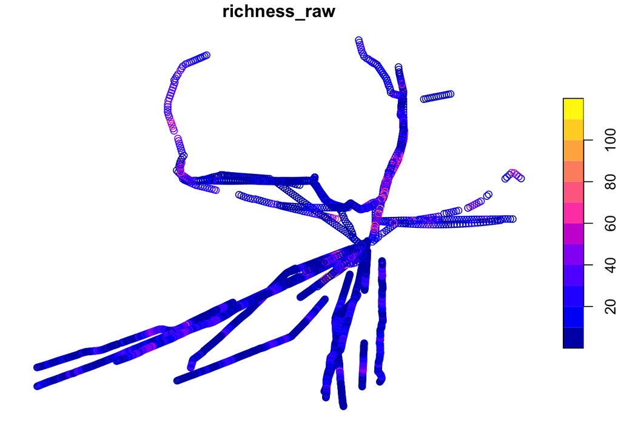

Here we have only plotted the richness column. If we used plot(sdat) it would create a panel for every variable in our dataframe. In sf, we can use square brackets [“richness_raw”] to select a single variable.

# Thematic maps for communication

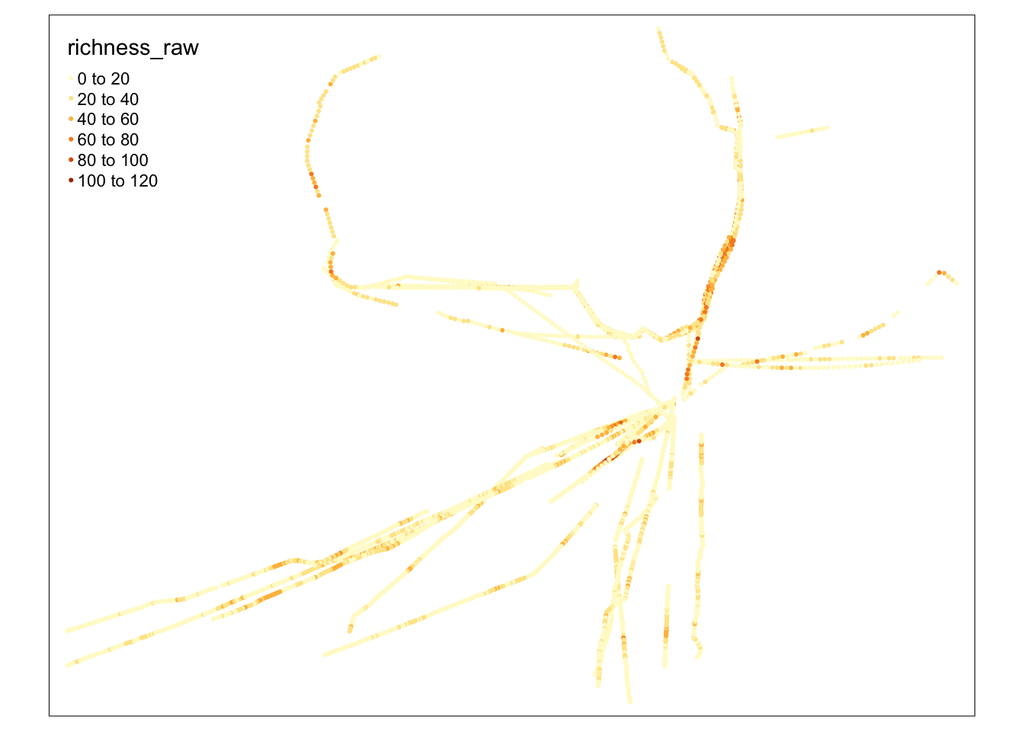

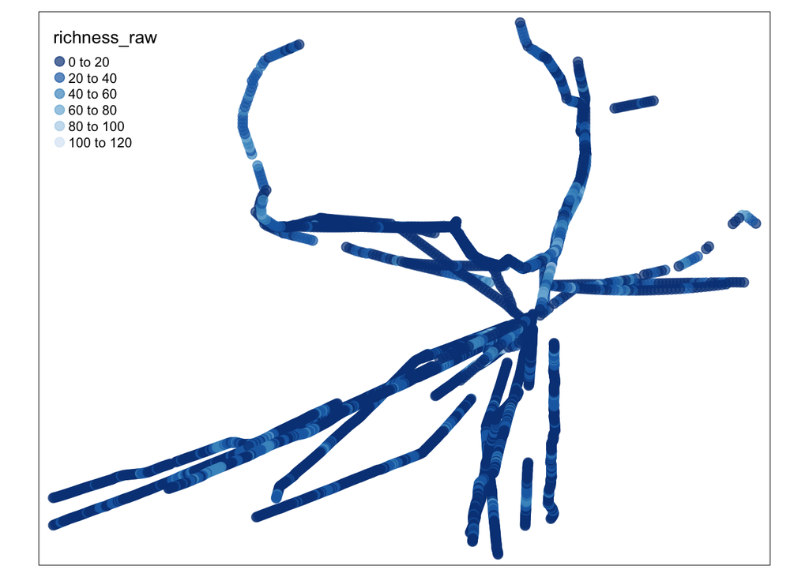

## Mapping spatial polygons as layers

We will load in a map of Australia and a map of Australia’s continental shelf using tmap to add these layers.

```
## Simple feature collection with 8 features and 1 field
## Geometry type: MULTIPOLYGON
## Dimension:     XY
## Bounding box:  xmin: 112.9211 ymin: -43.63192 xmax: 153.6389 ymax: -9.229614
## Geodetic CRS:  WGS 84
##   adm                       geometry
## 1 NSW MULTIPOLYGON (((141.0029 -3...
## 2 Vic MULTIPOLYGON (((140.9659 -3...
## 3 QLD MULTIPOLYGON (((153.5522 -2...
## 4  SA MULTIPOLYGON (((129.0013 -2...
## 5  WA MULTIPOLYGON (((129.0012 -1...
## 6 Tas MULTIPOLYGON (((148.3096 -4...
## 7  NT MULTIPOLYGON (((137.9962 -1...
## 8 ACT MULTIPOLYGON (((149.1253 -3...
```

```
## Simple feature collection with 1 feature and 1 field
## Geometry type: MULTIPOLYGON
## Dimension:     XY
## Bounding box:  xmin: 112.2242 ymin: -44.1284 xmax: 153.8942 ymax: -8.8798
## Geodetic CRS:  GRS 1980(IUGG, 1980)
##   FID                       geometry
## 1   0 MULTIPOLYGON (((112.2267 -2...
```

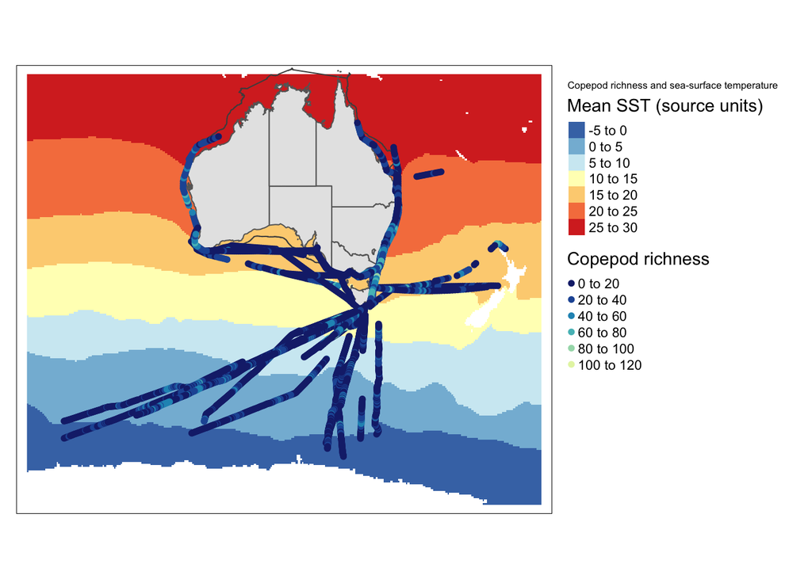

## Mapping polygons

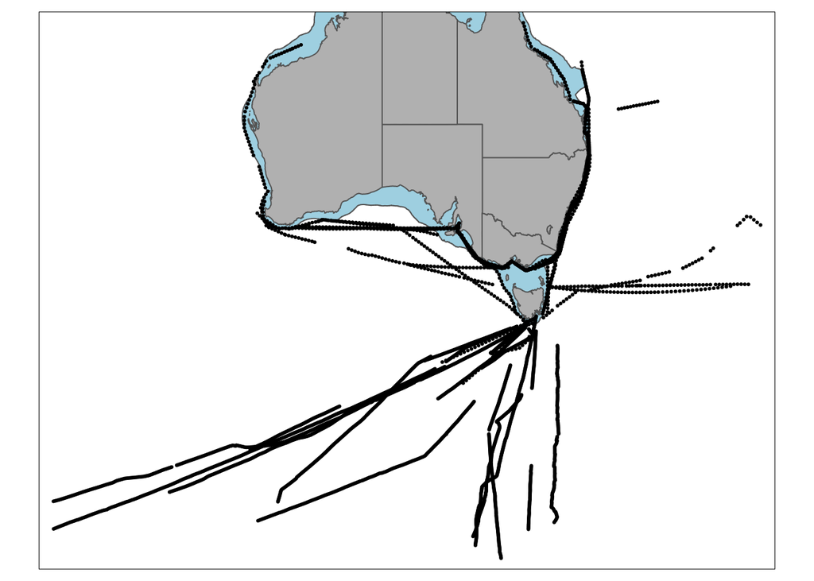

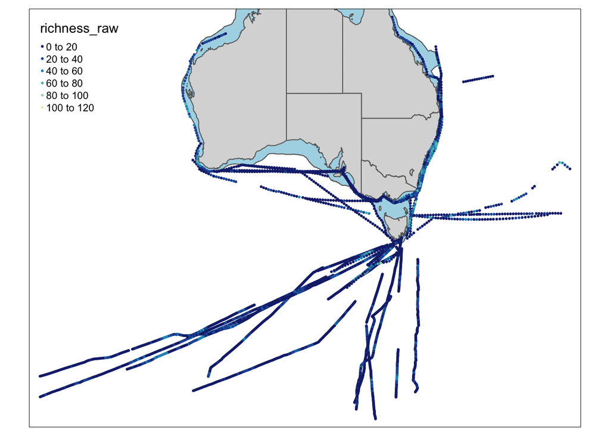

## REVISITING MY WORKSHOP 4 MAP ##

```
## Rows: 5,313
## Columns: 14
## $ silk_id         <dbl> 1, 1, 1, 1, 1, 1, 1, 1, 1, 1, 1, 1, …
## $ segment_no      <dbl> 1, 5, 9, 13, 17, 18, 26, 30, 33, 37,…
## $ sample_time_utc <chr> "26/06/2009 22:08", "26/06/2009 23:1…
## $ project         <chr> "AusCPR", "AusCPR", "AusCPR", "AusCP…
## $ route           <chr> "BRSY", "BRSY", "BRSY", "BRSY", "BRS…
## $ vessel          <chr> "ANL Windarra", "ANL Windarra", "ANL…
## $ meanlong        <dbl> 153.2466, 153.2466, 153.2466, 153.24…
## $ region          <chr> "East", "East", "East", "East", "Eas…
## $ richness_raw    <dbl> 3, 21, 27, 54, 24, 18, 36, 9, 24, 36…
## $ geometry        <POINT [°]> POINT (153.8139 -28.34227), PO…
## $ sample_datetime <dttm> 2009-06-26 22:08:00, 2009-06-26 23:…
## $ sample_date     <date> 2009-06-26, 2009-06-26, 2009-06-27,…
## $ sample_year     <fct> 2009, 2009, 2009, 2009, 2009, 2009, …
## $ sample_month    <dttm> 2009-06-01, 2009-06-01, 2009-06-01,…
```

```
## [1] "2007-11-25 07:53:00 UTC" "2016-07-31 09:01:00 UTC"
```

[interactive chart not shown]